# Social Capital and Crime in Germany

4 December 2015

## Outline

- Research Question
- Data
- Models
- Results

## Research Question

How do social networks and bonds in a given community determine the level of violent crime?

H0: *The more social capital in anygiven community, the less violent crime there would be observed.*

H1: *The higher the foundations density is in a district, the lower the murder rate.*

H2: *The lower the migration flow is in a district, the lower the murder rate.*

H3: *The higher the voter turnout is in a district, the lower the murder rate.*

## Data

We gathered data from three main sources:

1. German Federal Police's crime statistic ("Polizeiliche Kriminalstatistik" [PKS])
2. The Regional Database Germany published by the Federal Statistical Office and the statistical Offices of the Lander
3. German Federal Foundations Association ("Bundesverband Deutscher Stiftungen")

## Summary Statistics

| Statistic | Mean | St. Dev. | Min | Max |
| --- | --- | --- | --- | --- |
| MurderRate | 2.8 | 2.8 | 0.0 | 29.3 |
| ViolentCrimeRate | 146.0 | 71.2 | 41.6 | 473.4 |
| FoundationsDens | 21.2 | 14.9 | 2.7 | 89.2 |
| FlowRate | 12,105.8 | 2,909.1 | 6,427.0 | 26,411.0 |
| ForeignerRate | 7,180.5 | 4,607.7 | 860.0 | 31,271.0 |
| TurnoutPerc | 70.8 | 4.2 | 57.8 | 79.1 |
| UnemployedPerc | 7.1 | 3.2 | 1.5 | 16.8 |
| MarriageRate | 477.3 | 97.3 | 291.0 | 1,282.1 |
| MaleRate | 49.0 | 0.7 | 47.0 | 51.0 |
| YouthRate | 6.0 | 4.2 | 0.2 | 24.9 |

## Highest Murder Rates in Germany Districts

|  | District ID | District Name | Murder Rate | Murders in 2013 |
| --- | --- | --- | --- | --- |
| 1 | 9463 | Coburg | 29.27258 | 12 |
| 2 | 9478 | Lichtenfels | 18.00612 | 12 |
| 3 | 9363 | Weiden i.d.OPf. | 14.37952 | 6 |
| 4 | 8211 | Baden-Baden | 13.20456 | 7 |
| 5 | 9462 | Bayreuth | 12.57475 | 9 |
| 6 | 9262 | Passau | 12.13249 | 6 |
| 7 | 9476 | Kronach | 11.68156 | 8 |
| 8 | 9763 | Kempten (Allgäu) | 10.76195 | 7 |
| 9 | 9561 | Ansbach | 10.04041 | 4 |
| 10 | 6532 | Lahn-Dill-Kreis | 9.94720 | 25 |

## Correlation Matrix

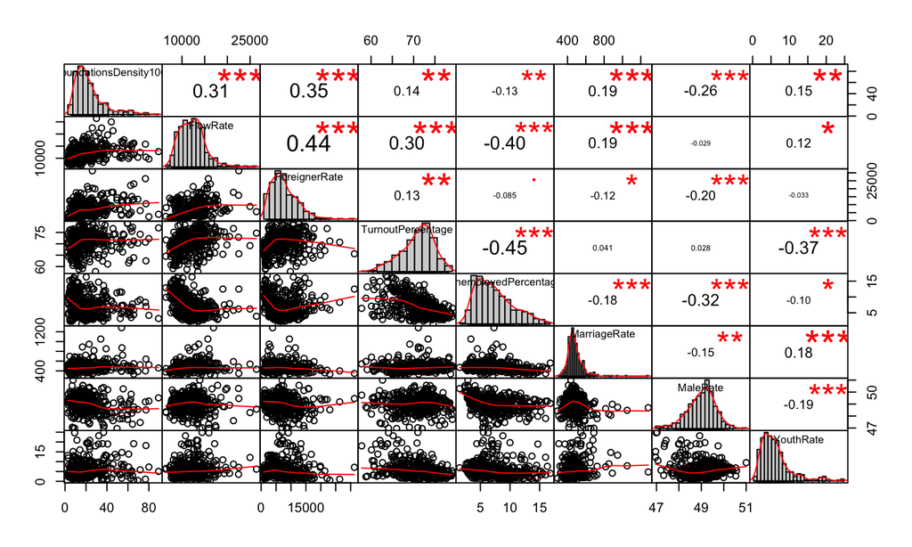

## Murder Rate distribution

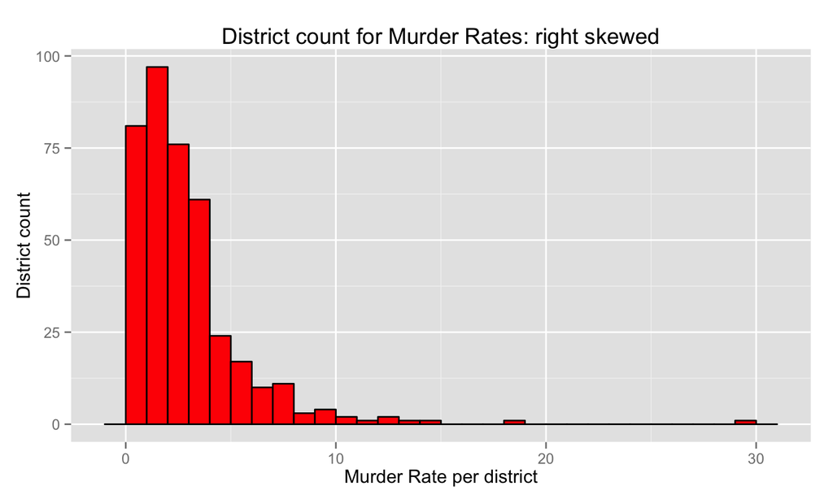

## Comparing OLS models (controls suppressed)

|  | *Dependent variable:* |  |  |
| --- | --- | --- | --- |
|  | MurderRate |  |  |
|  | (1) | (2) | (3) |
| FoundationsDensity100k | 0.01 |  |  |
|  | (0.01) |  |  |
| FlowRate |  | -0.0000 |  |
|  |  | (0.0001) |  |
| TurnoutPercentage |  |  | -0.11*** |
|  |  |  | (0.04) |
| Observations | 393 | 393 | 393 |
| R<sup>2</sup> | 0.14 | 0.14 | 0.16 |
| Adjusted R<sup>2</sup> | 0.13 | 0.13 | 0.15 |
| *Note:* | p<0.1; p<0.05; p<0.01 |  |  |

The control variables are: ForeignerRate, MarriageRate, MaleRate, YouthRate, UnemployedRate

## Poisson-based regression model (controls suppressed)

|  | *Dependent variable:* |
| --- | --- |
|  | MurderRate |
| FoundationsDensity100k | 0.005** |
|  | (0.002) |
| FlowRate | 0.0000 |
|  | (0.0000) |
| TurnoutPercentage | -0.04*** |
|  | (0.01) |
| Observations | 393 |
| Log Likelihood | -837.83 |
| Akaike Inf. Crit. | 1,693.66 |
| *Note:* | p<0.1; p<0.05; p<0.01 |

The control variables are: ForeignerRate, MarriageRate, MaleRate, YouthRate, UnemployedRate

## Negative Binomial (controls suppressed)

|  | *Dependent variable:* |
| --- | --- |
|  | MurderRate |
| FoundationsDensity100k | 0.01* |
|  | (0.003) |
| FlowRate | 0.0000 |
|  | (0.0000) |
| TurnoutPercentage | -0.04*** |
|  | (0.01) |
| Observations | 393 |
| Log Likelihood | -766.72 |
| theta | 2.32*** (0.35) |
| Akaike Inf. Crit. | 1,551.44 |
| *Note:* | p<0.1; p<0.05; p<0.01 |

The control variables are: ForeignerRate, MarriageRate, MaleRate, YouthRate, UnemployedRate

## Incident Rates

|  | IncidentRate |  |
| --- | --- | --- |
| (Intercept) | 7,700.9580 | ++ |
| FoundationsDensity100k | 1.0063 | + |
| FlowRate | 1 |  |
| TurnoutPercentage | 0.9592 | +++ |
| ForeignerRate | 1 |  |
| MarriageRate | 0.9999 |  |
| MaleRate | 0.8862 |  |
| YouthRate | 1.0474 | +++ |
| UnemployedPercentage | 1.0084 |  |

## Conclusion

- Voter turnout is best predictor
- Research problems persist: operationalisation, aggregation level, reverse causality, no panel data
- Research on crime is difficult, especially in Germany

## Discussion

- Better measurements for social capital?
- Aggregation on discrict level (~400) reasonable?
- Remedies for reverse causality?

Thank you for your attention!  
Any questions?